# Deliverable 2: deaths dataset, case-crossover dataset and mortality summary

- Show All Code
- Hide All Code
- View Source

Heatwaves, ozone and mortality in Santiago, 2009-2020

Author

Amaru Agüero Jiménez

Published

November 25, 2026

Second deliverable of the data analysis. Deaths of residents of the 33 study municipalities during the warm seasons (1 November to 31 March) of 2009 to 2020, from the death records of the Department of Health Statistics and Information (DEIS), and the analytic dataset of the space-time-stratified case-crossover design.

| Requested | Where |
| --- | --- |
| Clean DEIS deaths dataset: non-accidental and cardiopulmonary causes (ICD-10), urban Santiago, warm seasons 2009-2020 | Clean deaths dataset |
| Case-crossover analytic dataset, stratified in time and space: three or four control days per death, same day of the week, month, year and municipality | Case-crossover analytic dataset |
| Exposure at lags 0 to 3 | Exposure at lags 0 to 3 |
| Summary table of mortality | Mortality summary |
| R scripts | R scripts |

The tables and the figures of this page can be downloaded: each table has an **Excel** button above it, and each figure a **PNG, 600 dpi** button below it. Each part names the scripts and the files behind its tables and figures.

# 1 Clean deaths dataset

*Script: `Code/20_mortality_deis.R`. Dataset: `Data/Derived/deaths_clean.csv`. Tables: `Output/Tables/mortality_flow.csv` and `mortality_excluded_causes.csv`.*

The dataset is `Data/Derived/deaths_clean.csv`, written by `Code/20_mortality_deis.R`: one row per death, with the date, the municipality of residence, sex, age, place of death, the underlying cause (ICD-10) and one flag for each cause group of the analysis plan. Deaths outside non-accidental mortality stay in the file, flagged, so that every exclusion can be counted.

## 1.1 Source and selection

The input is the official DEIS file of deaths 1990-2023 (open data, one row per death, with date, sex, age, municipality of residence and underlying cause). The scripts read either that file or an extract of it with the same columns; the run behind this page used the extract of residents of the Metropolitan Region who died in 2009-2020.

```r
flow <- read_table("mortality_flow.csv")
kable(flow, format.args = list(big.mark = ","), col.names = c("Step", "Deaths"))
```

Table 1: Records kept at each step of the selection.

| Step | Deaths |
| --- | --- |
| Records in the input file | 473,568 |
| With date of death and municipality of residence | 473,568 |
| Residents of the 33 study municipalities | 400,074 |
| Died in 2009-2020 | 400,074 |
| Died in the warm season (1 November to 31 March) | 147,276 |
| Non-accidental cause (A00-R99) | 135,359 |
| Non-accidental, with age and sex recorded | 135,343 |

```r
excluded <- read_table("mortality_excluded_causes.csv")
kable(dcast(excluded, cause ~ year, value.var = "deaths", fill = 0),
      format.args = list(big.mark = ","))
```

Table 2: Deaths outside non-accidental mortality (A00-R99), by calendar year.

| cause | 2009 | 2010 | 2011 | 2012 | 2013 | 2014 | 2015 | 2016 | 2017 | 2018 | 2019 | 2020 |
| --- | --- | --- | --- | --- | --- | --- | --- | --- | --- | --- | --- | --- |
| Codes for special purposes (U), COVID-19 | 0 | 0 | 0 | 0 | 0 | 0 | 0 | 0 | 0 | 0 | 0 | 595 |
| Injuries (S00-T98) | 983 | 1,063 | 915 | 909 | 875 | 929 | 945 | 909 | 888 | 955 | 1,008 | 943 |

Non-accidental mortality follows the analysis plan: underlying cause between A00 and R99. Two groups fall outside it. Injuries, coded S00-T98 with their external cause in a second field, are the exclusion the plan asks for. The U codes are COVID-19 (U07.1 and U07.2): 595 deaths in the warm-season months of 2020 are therefore not part of the non-accidental series. Whether the months of the pandemic stay in the analysis is a decision for the principal investigator.

3 records have a recorded age above 110 years; they stay in the oldest age group.

# 2 Mortality summary

*Script: `Code/20_mortality_deis.R`. Tables: `Output/Tables/mortality_by_cause_year.csv` and `mortality_by_municipality_year.csv`. The table by age and sex, the series of deaths per day and the maps are computed in this page from `Data/Derived/deaths_clean.csv`.*

## 2.1 By cause, age and sex

```r
cause_year <- read_table("mortality_by_cause_year.csv")
cause_wide <- dcast(cause_year, cause ~ year, value.var = "deaths", fill = 0)
cause_wide[, Total := rowSums(.SD), .SDcols = setdiff(names(cause_wide), "cause")]
cause_wide <- cause_wide[match(names(cause_labels), cause)]
cause_wide[, cause := cause_labels[cause]]
kable(cause_wide, format.args = list(big.mark = ","))
```

Table 3: Deaths in the warm-season months by cause group and calendar year. The groups overlap: each sub-cause is part of its parent group.

| cause | 2009 | 2010 | 2011 | 2012 | 2013 | 2014 | 2015 | 2016 | 2017 | 2018 | 2019 | 2020 | Total |
| --- | --- | --- | --- | --- | --- | --- | --- | --- | --- | --- | --- | --- | --- |
| Non-accidental (A00-R99) | 10,232 | 10,544 | 10,791 | 10,990 | 11,185 | 11,350 | 11,581 | 11,446 | 11,530 | 11,629 | 12,107 | 11,974 | 135,359 |
| Cardiopulmonary (I00-I99, J00-J99) | 3,896 | 3,948 | 4,018 | 4,190 | 4,345 | 4,462 | 4,502 | 4,335 | 4,395 | 4,559 | 4,711 | 4,651 | 52,012 |
| Cardiovascular (I00-I99) | 2,972 | 3,053 | 3,090 | 3,129 | 3,233 | 3,361 | 3,426 | 3,324 | 3,249 | 3,281 | 3,260 | 3,167 | 38,545 |
| Ischemic heart disease (I20-I25) | 803 | 852 | 798 | 862 | 867 | 942 | 1,075 | 1,077 | 1,004 | 974 | 1,005 | 920 | 11,179 |
| Acute myocardial infarction (I21-I22) | 573 | 629 | 564 | 635 | 639 | 700 | 818 | 837 | 800 | 751 | 739 | 718 | 8,403 |
| Hypertensive diseases (I10-I15) | 510 | 488 | 469 | 518 | 583 | 718 | 751 | 727 | 737 | 771 | 727 | 738 | 7,737 |
| Cerebrovascular (I60-I69) | 918 | 990 | 1,054 | 1,051 | 1,057 | 1,020 | 988 | 915 | 904 | 868 | 851 | 805 | 11,421 |
| Ischemic stroke (I63) | 48 | 55 | 47 | 44 | 40 | 50 | 40 | 40 | 66 | 56 | 47 | 38 | 571 |
| Hemorrhagic stroke (I60-I61) | 260 | 267 | 280 | 249 | 249 | 287 | 261 | 241 | 220 | 236 | 231 | 232 | 3,013 |
| Respiratory (J00-J99) | 924 | 895 | 928 | 1,061 | 1,112 | 1,101 | 1,076 | 1,011 | 1,146 | 1,278 | 1,451 | 1,484 | 13,467 |
| COPD (J41-J44) | 311 | 329 | 307 | 315 | 333 | 327 | 353 | 317 | 341 | 326 | 336 | 330 | 3,925 |

```r
age_sex <- dcast(non_accidental[, .N, by = .(age_group, sex)], age_group ~ sex, value.var = "N", fill = 0)
age_sex[, total := rowSums(.SD), .SDcols = setdiff(names(age_sex), "age_group")]
age_sex[, share := 100 * total / sum(total)]
kable(age_sex, digits = 1, format.args = list(big.mark = ","))
```

Table 4: Non-accidental deaths by age group and sex, warm seasons 2009-2020.

| age_group | female | male | undetermined | total | share |
| --- | --- | --- | --- | --- | --- |
| 0-64 | 13,957 | 20,593 | 16 | 34,566 | 25.5 |
| 65-84 | 29,944 | 32,583 | 0 | 62,527 | 46.2 |
| 85+ | 25,985 | 12,281 | 0 | 38,266 | 28.3 |

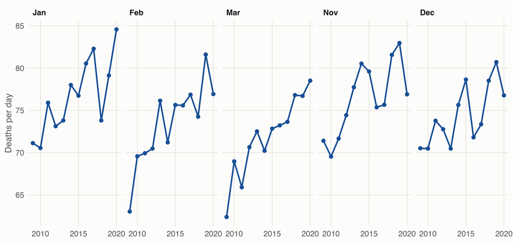

Figure 1: Non-accidental deaths per day in the 33 municipalities by month of the warm season and calendar year.

```r
daily <- non_accidental[, .N, by = date]
monthly <- daily[, .(per_day = mean(N)), by = .(year = year(date), month = month(date))]
monthly[, month := factor(month, levels = c(1, 2, 3, 11, 12),
                          labels = c("Jan", "Feb", "Mar", "Nov", "Dec"))]
ggplot(monthly, aes(year, per_day)) +
  geom_line(colour = ramp_blue[6], linewidth = 0.8) +
  geom_point(colour = ramp_blue[6], size = 1.6) +
  facet_wrap(~month, nrow = 1) +
  scale_x_continuous(breaks = c(2010, 2015, 2020)) +
  labs(x = NULL, y = "Deaths per day")
```

## 2.2 By municipality

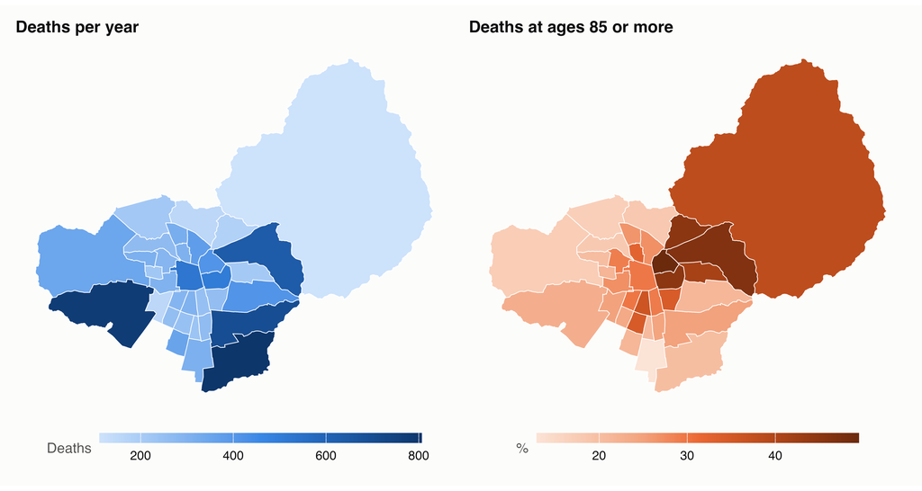

Figure 2: Non-accidental deaths per year in the warm-season months, 2009-2020, and share of deaths at ages 85 or more.

```r
shapes_env <- new.env()
load(input_path("municipality_shapes"), envir = shapes_env)
shapes <- shapes_env$comunas_santiago[, "cod_comuna"]
shapes$com <- as.integer(shapes$cod_comuna)
by_mun <- non_accidental[, .(per_year = .N / 12, oldest = 100 * mean(age_group == "85+", na.rm = TRUE)),
                         by = com]
map_values <- function(column, title, legend, hue, digits) {
  ggplot(merge(shapes, by_mun, by = "com")) +
    geom_sf(aes(fill = .data[[column]]), colour = "#ffffff", linewidth = 0.25) +
    scale_fill_magnitude(name = legend, hue = hue,
                         labels = function(x) formatC(x, format = "f", digits = digits)) +
    labs(title = title) + theme_map()
}
patchwork::wrap_plots(
  map_values("per_year", "Deaths per year", "Deaths", "blue", 0),
  map_values("oldest", "Deaths at ages 85 or more", "%", "orange", 0), ncol = 2
)
```

```r
mun_year <- read_table("mortality_by_municipality_year.csv")
mun_wide <- dcast(mun_year[group == "non_accidental"], municipality ~ year, value.var = "deaths", fill = 0)
kableExtra::scroll_box(
  kableExtra::kable_styling(kable(mun_wide, format = "html", format.args = list(big.mark = ",")),
                            bootstrap_options = c("striped", "condensed"), font_size = 12),
  height = "380px"
)
```

Table 5: Non-accidental deaths by municipality and calendar year, warm-season months.

| municipality | 2009 | 2010 | 2011 | 2012 | 2013 | 2014 | 2015 | 2016 | 2017 | 2018 | 2019 | 2020 |
| --- | --- | --- | --- | --- | --- | --- | --- | --- | --- | --- | --- | --- |
| Cerrillos | 149 | 147 | 149 | 149 | 167 | 164 | 148 | 171 | 159 | 155 | 147 | 166 |
| Cerro Navia | 302 | 275 | 296 | 305 | 303 | 321 | 288 | 321 | 312 | 326 | 315 | 351 |
| Conchalí | 307 | 294 | 318 | 343 | 287 | 311 | 354 | 330 | 324 | 293 | 349 | 294 |
| El Bosque | 332 | 337 | 346 | 336 | 347 | 344 | 369 | 366 | 345 | 368 | 357 | 394 |
| Estación Central | 305 | 305 | 309 | 294 | 306 | 328 | 345 | 276 | 272 | 300 | 272 | 298 |
| Huechuraba | 147 | 134 | 131 | 146 | 149 | 156 | 152 | 154 | 141 | 191 | 176 | 186 |
| Independencia | 336 | 302 | 308 | 312 | 293 | 293 | 331 | 254 | 313 | 307 | 324 | 270 |
| La Cisterna | 226 | 226 | 246 | 237 | 224 | 250 | 273 | 281 | 250 | 245 | 257 | 213 |
| La Florida | 579 | 655 | 651 | 670 | 702 | 673 | 697 | 699 | 738 | 720 | 792 | 801 |
| La Granja | 248 | 234 | 258 | 224 | 281 | 273 | 295 | 279 | 249 | 275 | 261 | 280 |
| La Pintana | 278 | 270 | 301 | 294 | 322 | 305 | 335 | 285 | 297 | 322 | 329 | 356 |
| La Reina | 201 | 210 | 200 | 199 | 210 | 189 | 212 | 238 | 215 | 217 | 234 | 220 |
| Las Condes | 507 | 605 | 603 | 620 | 670 | 625 | 644 | 664 | 656 | 654 | 698 | 688 |
| Lo Barnechea | 96 | 92 | 88 | 112 | 109 | 99 | 118 | 119 | 103 | 130 | 145 | 133 |
| Lo Espejo | 236 | 255 | 277 | 262 | 250 | 281 | 262 | 275 | 244 | 235 | 251 | 243 |
| Lo Prado | 208 | 192 | 242 | 207 | 252 | 235 | 212 | 232 | 216 | 227 | 215 | 214 |
| Macul | 217 | 248 | 258 | 258 | 230 | 239 | 249 | 254 | 259 | 273 | 281 | 264 |
| Maipú | 626 | 692 | 675 | 725 | 778 | 758 | 840 | 803 | 850 | 783 | 867 | 909 |
| Pedro Aguirre Cerda | 281 | 292 | 307 | 294 | 268 | 311 | 316 | 263 | 296 | 300 | 292 | 267 |
| Peñalolén | 348 | 363 | 383 | 403 | 388 | 424 | 416 | 436 | 456 | 413 | 445 | 466 |
| Providencia | 401 | 399 | 387 | 379 | 439 | 418 | 388 | 424 | 429 | 422 | 442 | 421 |
| Pudahuel | 282 | 320 | 303 | 350 | 335 | 352 | 328 | 375 | 358 | 385 | 380 | 391 |
| Puente Alto | 660 | 702 | 760 | 744 | 763 | 813 | 827 | 859 | 870 | 878 | 927 | 866 |
| Quilicura | 179 | 172 | 152 | 187 | 201 | 219 | 246 | 224 | 242 | 243 | 254 | 272 |
| Quinta Normal | 275 | 281 | 291 | 280 | 289 | 273 | 325 | 264 | 291 | 282 | 309 | 282 |
| Recoleta | 405 | 383 | 366 | 414 | 344 | 366 | 354 | 380 | 359 | 402 | 416 | 365 |
| Renca | 261 | 231 | 254 | 253 | 259 | 262 | 249 | 276 | 298 | 309 | 274 | 272 |
| San Joaquín | 216 | 263 | 235 | 260 | 227 | 243 | 290 | 257 | 248 | 242 | 232 | 248 |
| San Miguel | 243 | 256 | 303 | 294 | 340 | 316 | 325 | 246 | 325 | 312 | 347 | 309 |
| San Ramón | 220 | 231 | 219 | 230 | 249 | 239 | 240 | 225 | 217 | 233 | 236 | 250 |
| Santiago | 505 | 520 | 513 | 545 | 529 | 530 | 482 | 540 | 507 | 540 | 560 | 543 |
| Vitacura | 165 | 173 | 181 | 178 | 158 | 201 | 190 | 172 | 183 | 177 | 195 | 192 |
| Ñuñoa | 491 | 485 | 481 | 486 | 516 | 539 | 481 | 504 | 508 | 470 | 528 | 550 |

The same table for every cause group, age group and sex is in `Output/Tables/mortality_by_municipality_year.csv`. Counts are deaths, not rates: population denominators enter with the attributable burden (deliverable 3).

# 3 Case-crossover analytic dataset

*Script: `Code/21_case_crossover_dataset.R`, with the functions `build_case_crossover()` and `lagged_exposure()` of `Code/01_functions.R`. Datasets: `Data/Derived/case_crossover.csv` and `exposure_lagged.csv`. Table: `Output/Tables/case_crossover_summary.csv`.*

Each non-accidental death is one stratum. Its referent days are all the days of the same municipality, calendar year, month and day of the week: the day of death and three or four control days. A month is either inside or outside the warm season, so every control day is a warm-season day.

```r
kable(read_table("case_crossover_summary.csv"), format.args = list(big.mark = ","),
      col.names = c("Item", "Value"))
```

Table 6: Size of the case-crossover dataset.

| Item | Value |
| --- | --- |
| Deaths (strata) | 135,359 |
| Rows (deaths and referent days) | 591,719 |
| Deaths with 3 control days | 85,076 |
| Deaths with 4 control days | 50,283 |
| Municipality-days used as referent | 59,754 |
| Lagged exposure columns | 188 |

```r
cc <- fread(derived_path("case_crossover.csv"), encoding = "UTF-8", nrows = 9)
kable(cc[, .(id, com, case_date, date, case, sex, age_group, icd3)],
      caption = "First rows of case_crossover.csv: two deaths with their referent days.")
```

First rows of case_crossover.csv: two deaths with their referent days.

| id | com | case_date | date | case | sex | age_group | icd3 |
| --- | --- | --- | --- | --- | --- | --- | --- |
| 1 | 13101 | 2009-01-01 | 2009-01-01 | 1 | female | 65-84 | C24 |
| 1 | 13101 | 2009-01-01 | 2009-01-08 | 0 | female | 65-84 | C24 |
| 1 | 13101 | 2009-01-01 | 2009-01-15 | 0 | female | 65-84 | C24 |
| 1 | 13101 | 2009-01-01 | 2009-01-22 | 0 | female | 65-84 | C24 |
| 1 | 13101 | 2009-01-01 | 2009-01-29 | 0 | female | 65-84 | C24 |
| 2 | 13101 | 2009-01-01 | 2009-01-01 | 1 | female | 85+ | C41 |
| 2 | 13101 | 2009-01-01 | 2009-01-08 | 0 | female | 85+ | C41 |
| 2 | 13101 | 2009-01-01 | 2009-01-15 | 0 | female | 85+ | C41 |
| 2 | 13101 | 2009-01-01 | 2009-01-22 | 0 | female | 85+ | C41 |

## 3.1 Exposure at lags 0 to 3

`Data/Derived/case_crossover.csv` holds the structure and the attributes of each death (sex, age group, cause flags). `Data/Derived/exposure_lagged.csv` holds, for every municipality-day used as a referent, each exposure variable at lags 0 to 3 (`<variable>_lag<k>` is the exposure k days earlier). Joining the two on municipality and day gives the model dataset for any definition:

```r
library(survival)
cc <- fread("Data/Derived/case_crossover.csv")
lagged <- fread("Data/Derived/exposure_lagged.csv")
model_data <- merge(cc, lagged[, .(com, date, hw = hw_p95_2d_lag1, oz = o3_idw_gt_p75_lag1)],
                    by = c("com", "date"))
clogit(case ~ hw + oz + strata(id), data = model_data)
```

# 4 Method checks

*Script: `tests/test_methods.R`, run here and at the start of every run of `Code/run_all.R`.*

`tests/test_methods.R` checks the functions behind this page and the models of deliverable 3 against independent calculations: the referent selection, the lagging, the equivalence between the fit on individual records and the faster weighted fit used in the models, the recovery of known odds ratios from simulated deaths, and the delta-method intervals against `msm::deltamethod`.

**Run tests/test_methods.R**

```r
checks <- system2(file.path(R.home("bin"), "Rscript"),
                  shQuote(here::here("tests", "test_methods.R")), stdout = TRUE, stderr = TRUE)
if (!is.null(attr(checks, "status"))) stop(paste(checks, collapse = "\n"))
cat(grep("^ok|^All|simulated", checks, value = TRUE), sep = "\n")
```

```
ok   consecutive_flag, n = 2, equals the run-length definition
ok   consecutive_flag, n = 3, equals the run-length definition
ok   consecutive_flag, n = 4, equals the run-length definition
ok   consecutive_flag returns NA when the window holds a missing day
ok   excess_heat_factor matches the hand calculation
ok   daily_from_hourly: 24-hour mean and MDA8 of a known day
ok   daily_from_hourly: a day with 10 valid hours has no 24-hour mean
ok   icd10_in_ranges: non-accidental A00-R99
ok   icd10_in_ranges: several ranges
ok   build_case_crossover: referents share year, month and weekday with the day of death
ok   build_case_crossover: the Thursdays of January 2015
ok   lagged_exposure: lag k is the value k days earlier in the same municipality
ok   additive_interaction: REOI = OR11 - OR10 - OR01 + 1
ok   additive_interaction: delta-method intervals equal msm::deltamethod
ok   collapsed weighted fit equals the individual conditional logistic fit (coefficients)
ok   collapsed weighted fit equals the individual fit (standard errors)
ok   number of deaths carried by the collapsed fit
     simulated deaths: 74578  estimates: 1.086, 1.035, 1.296  truth: 1.100, 1.050, 1.300  z: -0.78, -1.37, -0.21
ok   estimates recover the true odds ratios (within 3 standard errors)
ok   the REOI interval covers the true value
ok   compound_results without adjustment equals the direct calculation
ok   compound_results keeps the three categories first when a covariate is added
ok   attributable_deaths: excess = expected x (OR - 1), summed over cells
ok   attributable_deaths: attributable = observed x (OR - 1) / OR
ok   attributable_deaths: categories add up to 'any', groups add up to the total
     excess deaths: 271.3  delta-method SE: 47.72  simulated SE: 47.85
ok   attributable_deaths: delta-method standard error within 2% of the simulated one
ok   burden: Population x Age share x Baseline rate x (OR - 1) x Days does not depend on the population
ok   local_percentile: share of the reference values of the same municipality at or below
ok   combine_coefficients: sum of two coefficients and its standard error
ok   distributed lags: the model with all the lags recovers the true lag structure
ok   distributed lags: the single-lag model at lag 2 picks up the earlier lags
ok   distributed lags: the cumulative interval covers the true cumulative odds ratio
ok   dlnm cross-basis and the hand-built spline give the same cumulative odds ratios
ok   the cumulative interval at P90 covers the true value
ok   run_parallel returns the results of lapply, in the same order
ok   run_parallel keeps a job that returns NULL
ok   run_parallel stops and names the job that failed
ok   run_parallel runs again the jobs of a worker process that died, and loses none
ok   verify_input accepts a file and a folder that match the manifest
```

[output cut: 8 more lines]

```
ok   compare_tables tells identical tables, last-digit noise and real differences apart
ok   compare_tables reports the size of the largest difference
ok   compare_tables compares as numbers a column of numbers that was read as text
ok   compare_tables wants an identifier of whole numbers to match exactly
ok   every package of the project is installed, and none is installed again
ok   a missing package stops with the command that installs it, when installing is not allowed
ok   the list of packages names every package the code loads
ok   Quarto is found on this machine
ok   one thread is asked of the linear algebra library before the worker processes start
ok   device_opens: the standard pdf device opens, a device that only warns does not
ok   pdf_figure_device names a device that opens on this machine
ok   write_figure: a PDF and a PNG with the size and the resolution asked
ok   kriging_sd: a variance below zero within rounding counts as zero, missing stays missing
ok   kriging_sd stops when a variance is below zero by more than the rounding
All checks passed.
```

# 5 R scripts

The scripts are in [`Code/`](https://github.com/AmaruSimonAgueroJimenez/Heatwave-ozone-mortality-Chile/tree/main/Code) of the repository. They are not executed when this page is rendered: `Code/run_all.R` runs them in order and this page reads their outputs. The code of each one is folded below.

| Script | Purpose |
| --- | --- |
| `Code/20_mortality_deis.R` | Deaths of residents of the study municipalities by cause, age and sex. |
| `Code/21_case_crossover_dataset.R` | Case-crossover dataset and lagged exposures. |

**Code/20_mortality_deis.R**

```r
# 20_mortality_deis.R
# Deaths of residents of the study municipalities during the warm seasons of
# 2009-2020, with cause, age and sex groups.
#
# Inputs
#   inputs$deis_deaths   DEIS death records (official open-data file, or an
#                        extract of it with the same columns), semicolon
#                        separated, Latin-1
# Outputs
#   Data/Derived/deaths_clean.csv                 one row per death
#   Output/Tables/mortality_flow.csv              records kept at each step
#   Output/Tables/mortality_excluded_causes.csv   causes outside A00-R99
#   Output/Tables/mortality_by_cause_year.csv
#   Output/Tables/mortality_by_municipality_year.csv
#
# The underlying cause (DIAG1) defines the cause groups of the analysis plan.
# Deaths from injuries and external causes (S00-T98 in DIAG1, with the
# external cause V01-Y98 in DIAG2) fall outside non-accidental mortality
# (A00-R99), and so do the U codes (COVID-19 in 2020). They stay in the file,
# flagged, so that every exclusion can be counted.

source(here::here("Code", "00_setup.R"))
source(here::here("Code", "01_functions.R"))

municipalities <- study_municipalities()
study_years <- get_param("mortality", "years")
warm_months <- get_param("study", "warm_season_months")
cause_groups <- get_param("mortality", "cause_groups")
age_breaks <- unlist(get_param("mortality", "age_breaks"))
age_labels <- unlist(get_param("mortality", "age_labels"))
stopifnot(length(age_labels) == length(age_breaks))

needed <- c("FECHA_DEF", "SEXO_NOMBRE", "EDAD_TIPO", "EDAD_CANT", "COD_COMUNA",
            "DIAG1", "DIAG2", "LUGAR_DEFUNCION")
header <- names(fread(input_path("deis_deaths"), sep = ";", encoding = "Latin-1", nrows = 0))
if (!all(needed %in% header)) {
  stop("Columns missing from the DEIS file: ",
       paste(setdiff(needed, header), collapse = ", "), call. = FALSE)
}
raw <- fread(input_path("deis_deaths"), sep = ";", encoding = "Latin-1", select = needed)

# ---- 1. Selection, counted step by step -------------------------------------

flow <- list()
count_step <- function(step, dt) {
  flow[[length(flow) + 1]] <<- data.table(step = step, deaths = nrow(dt))
  invisible(dt)
}
deaths <- count_step("Records in the input file", raw)
deaths[, date := as.Date(FECHA_DEF)]
deaths <- count_step("With date of death and municipality of residence",
                     deaths[!is.na(date) & !is.na(COD_COMUNA)])
deaths <- count_step("Residents of the 33 study municipalities",
                     deaths[COD_COMUNA %in% municipalities$code])
deaths <- count_step(sprintf("Died in %d-%d", study_years[1], study_years[2]),
                     deaths[year(date) >= study_years[1] & year(date) <= study_years[2]])
deaths <- count_step("Died in the warm season (1 November to 31 March)",
                     deaths[is_warm_season(date, warm_months)])

# ---- 2. Cause, age and sex --------------------------------------------------

stopifnot(all(grepl("^[A-Z][0-9]{2}[0-9X]$", deaths$DIAG1)))
deaths[, icd10 := DIAG1]
deaths[, icd3 := substr(DIAG1, 1, 3)]
for (group in names(cause_groups)) {
  deaths[, (group) := icd10_in_ranges(icd3, unlist(cause_groups[[group]]))]
}

# Age in completed years; ages recorded in months, days or hours are under one
stopifnot(all(deaths$EDAD_TIPO %in% c(1, 2, 3, 4, NA)))
deaths[, age_years := fcase(EDAD_TIPO == 1, as.numeric(EDAD_CANT),
                            EDAD_TIPO %in% 2:4, 0)]
deaths[, age_group := cut(age_years, c(age_breaks, Inf), labels = age_labels, right = FALSE)]
deaths[, sex := fcase(SEXO_NOMBRE == "Hombre", "male", SEXO_NOMBRE == "Mujer", "female",
                      default = "undetermined")]
deaths[, place := fcase(LUGAR_DEFUNCION == "Casa habitación", "home",
                        LUGAR_DEFUNCION == "Hospital o Clínica", "hospital or clinic",
                        default = "other")]

count_step("Non-accidental cause (A00-R99)", deaths[non_accidental == TRUE])
count_step("Non-accidental, with age and sex recorded",
           deaths[non_accidental == TRUE & !is.na(age_group) & sex != "undetermined"])
flow <- rbindlist(flow)
fwrite(flow, file.path(dir_tables, "mortality_flow.csv"))

excluded <- deaths[non_accidental == FALSE, .(deaths = .N), keyby = .(
  cause = fcase(substr(icd3, 1, 1) %in% c("S", "T"), "Injuries (S00-T98)",
                substr(icd3, 1, 1) == "U", "Codes for special purposes (U), COVID-19",
                default = "Other"),
  year = year(date))]
fwrite(excluded, file.path(dir_tables, "mortality_excluded_causes.csv"))

# ---- 3. Save ----------------------------------------------------------------

deaths <- merge(deaths, municipalities, by.x = "COD_COMUNA", by.y = "code")
setnames(deaths, c("COD_COMUNA", "name"), c("com", "municipality"))
setorder(deaths, date, com, icd10, age_years, sex)
deaths[, id := .I]
deaths[, year := year(date)]
keep <- c("id", "date", "year", "com", "municipality", "sex", "age_years", "age_group",
          "place", "icd10", "icd3", names(cause_groups))
deaths_clean <- deaths[, ..keep]
fwrite(deaths_clean, file.path(dir_derived, "deaths_clean.csv"))

# ---- 4. Summary tables ------------------------------------------------------

by_cause_year <- rbindlist(lapply(names(cause_groups), function(group) {
  deaths_clean[get(group) == TRUE, .(cause = group, deaths = .N), keyby = year]
}))
setcolorder(by_cause_year, c("cause", "year", "deaths"))
fwrite(by_cause_year, file.path(dir_tables, "mortality_by_cause_year.csv"))

non_accidental <- deaths_clean[non_accidental == TRUE]
summarise_by <- function(group_type, group_column) {
  non_accidental[, .(deaths = .N), keyby = c("com", "municipality", "year", group_column)][
    , .(com, municipality, year, group_type = group_type, group = as.character(get(group_column)), deaths)]
}
by_municipality_year <- rbind(
  non_accidental[, .(group_type = "cause", group = "non_accidental", deaths = .N),
                 keyby = .(com, municipality, year)],
  rbindlist(lapply(setdiff(names(cause_groups), "non_accidental"), function(group) {
    deaths_clean[get(group) == TRUE, .(group_type = "cause", group = group, deaths = .N),
                 keyby = .(com, municipality, year)]
  })),
  summarise_by("age_group", "age_group"),
  summarise_by("sex", "sex")
)
fwrite(by_municipality_year, file.path(dir_tables, "mortality_by_municipality_year.csv"))

message("deaths_clean.csv: ", nrow(deaths_clean), " deaths, ",
        sum(deaths_clean$non_accidental), " non-accidental")
print(flow)
```

**Code/21_case_crossover_dataset.R**

```r
# 21_case_crossover_dataset.R
# Analytic dataset of the space-time-stratified case-crossover design.
#
# Inputs
#   Data/Derived/deaths_clean.csv         (script 20)
#   Data/Derived/exposure_2009_2020.csv   (script 13)
# Outputs
#   Data/Derived/case_crossover.csv       one row per death and referent day
#   Data/Derived/exposure_lagged.csv      exposures at lags 0 to 3 by municipality-day
#   Output/Tables/case_crossover_summary.csv
#
# Each non-accidental death is its own stratum. The referent days are all the
# days of the same municipality, calendar year, month and day of the week:
# the day of death (case = 1) and three or four control days (case = 0).
# Exposures are attached to any model by joining exposure_lagged.csv on the
# municipality and the day: the column <variable>_lag<k> is the exposure k
# days before that day.

source(here::here("Code", "00_setup.R"))
source(here::here("Code", "01_functions.R"))

lags <- unlist(get_param("design", "lags_days"))
stopifnot(identical(unlist(get_param("design", "control_strata")),
                    c("municipality", "year", "month", "day_of_week")))

deaths <- fread(derived_path("deaths_clean.csv"), encoding = "UTF-8")
deaths[, date := as.Date(date)]
deaths <- deaths[non_accidental == TRUE]

exposure <- fread(derived_path("exposure_2009_2020.csv"), encoding = "UTF-8")
exposure[, date := as.Date(date)]

# ---- 1. Referent days -------------------------------------------------------

cc <- build_case_crossover(deaths[, .(id, com, date)])
# Every referent day must be a day of the exposure dataset
stopifnot(nrow(fsetdiff(unique(cc[, .(com, date)]), exposure[, .(com, date)])) == 0)

person <- deaths[, !c("com", "date", "year", "municipality", "icd10")]
cc <- merge(cc, person, by = "id")
setorder(cc, id, date)
fwrite(cc, file.path(dir_derived, "case_crossover.csv"))

# ---- 2. Lagged exposures ----------------------------------------------------

exposure_variables <- c(
  grep("^hw_", names(exposure), value = TRUE),
  grep("_gt_p[0-9]+$", names(exposure), value = TRUE),
  "tmax", "tad",
  as.vector(outer(c("o3", "o3obs", "o3mda8", "pm25", "no2", "hum"), c("idw", "ok"),
                  paste, sep = "_"))
)
lagged <- lagged_exposure(exposure, exposure_variables, lags)
# Keep the municipality-days that are a referent day of at least one death
lagged <- lagged[unique(cc[, .(com, date)]), on = .(com, date)]
fwrite(lagged, file.path(dir_derived, "exposure_lagged.csv"))

# ---- 3. Summary -------------------------------------------------------------

controls <- cc[, .(controls = .N - 1L), by = id]
summary_table <- data.table(
  item = c("Deaths (strata)", "Rows (deaths and referent days)",
           "Deaths with 3 control days", "Deaths with 4 control days",
           "Municipality-days used as referent", "Lagged exposure columns"),
  value = c(uniqueN(cc$id), nrow(cc), sum(controls$controls == 3), sum(controls$controls == 4),
            nrow(lagged), ncol(lagged) - 2L)
)
fwrite(summary_table, file.path(dir_tables, "case_crossover_summary.csv"))

message("case_crossover.csv: ", nrow(cc), " rows for ", uniqueN(cc$id), " deaths")
print(summary_table)
```